# quiz02

Ekaterina Bochvaroska

2025-04-20

```r
my.data <- read.delim("~/quiz02/data.txt", header = TRUE, sep = "\t", stringsAsFactors = FALSE)
x <- 9
z <- 4
my.data <- my.data[unique(c(seq(x, nrow(my.data), by = 10),
seq(z, nrow(my.data), by = 10))), ]
dim(my.data)
```

```
## [1] 105  25
```

**Question 1**  
Let the data for **height** for **males** represent your sample. With an appropriate statistical test, check if the population mean of male students is **greater than180 cm**. Use $\alpha=0.05$. Write down the hypotheses and conclusion in words.

```r
male_heights <- subset(my.data, Sex=="male")$Height

cat("H0: µ_male <= 180 cm\n")
```

```
## H0: µ_male <= 180 cm
```

```r
cat("H1: µ_male > 180 cm\n\n")
```

```
## H1: µ_male > 180 cm
```

```r
test1 <- t.test(male_heights,
                mu = 180,
                alternative = "greater",
                conf.level = 0.95)
print(test1)
```

```
##
##  One Sample t-test
##
## data:  male_heights
## t = 2.7218, df = 37, p-value = 0.004921
## alternative hypothesis: true mean is greater than 180
## 95 percent confidence interval:
##  181.0804      Inf
## sample estimates:
## mean of x
##  182.8421
```

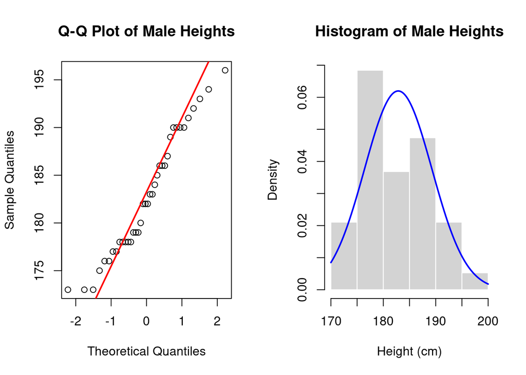

```r
male_heights <- subset(my.data, Sex == "male")$Height

par(mfrow = c(1, 2))

qqnorm(male_heights, main = "Q-Q Plot of Male Heights")
qqline(male_heights, col = "red", lwd = 2)

hist(male_heights, probability = TRUE,
     main = "Histogram of Male Heights",
     xlab = "Height (cm)",
     col = "lightgray", border = "white")

curve(dnorm(x,
            mean = mean(male_heights),
            sd   = sd(male_heights)),
      add = TRUE, col = "blue", lwd = 2)
```

```r
par(mfrow = c(1, 1))
```

**Question 3** Let say we take sample of size 30 from the geometric distribution with some chosen parameter and repeat that 200 times. Draw a plot of the distribution of Xn,that is draw a histogram of the 200 values of sample means. What are expected value and variance of Xn? What distribution do you get - name it. Hint: some important theorem tells you what the distribution is.in R geometric distribution is denoted as P(X = k) = p · (1 - p)^k ,which means that the expected value is equal to E(X) = 1p/p.

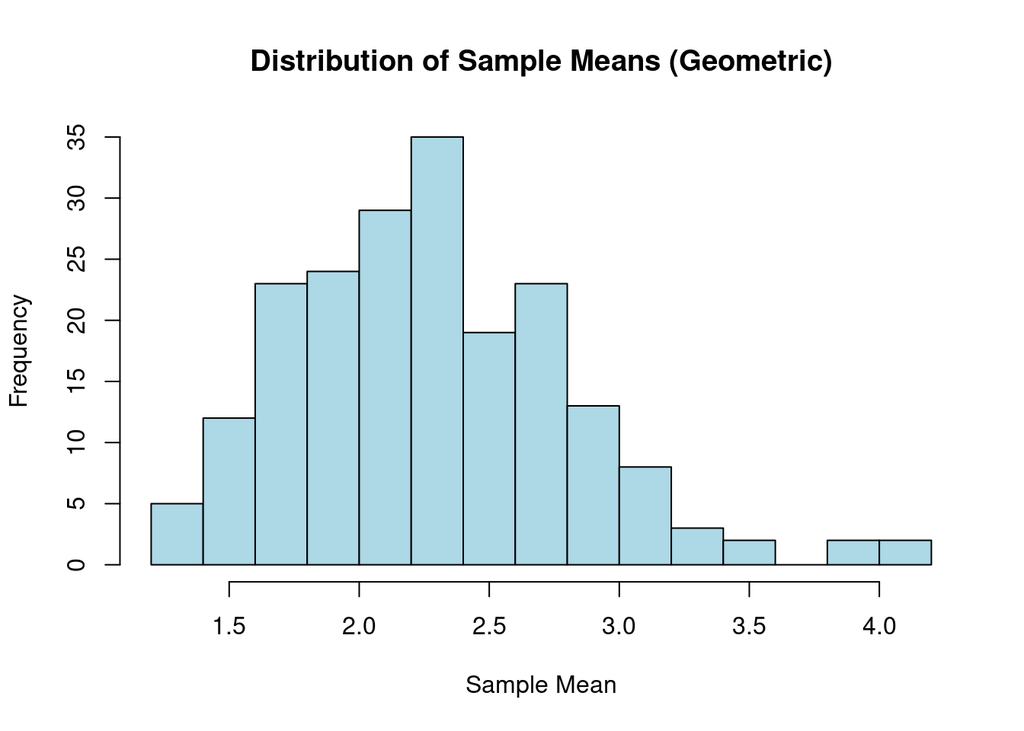

```r
p <- 0.3
n <- 30
B <- 200

set.seed(123)
sample_means <- replicate(B, mean(rgeom(n, prob = p)))

hist(sample_means,
     breaks = 20,
     col = "lightblue",
     main = "Distribution of Sample Means (Geometric)",
     xlab = "Sample Mean")
```

```r
expected_value <- (1 - p) / p
variance_single <- (1 - p) / (p^2)
variance_mean <- variance_single / n

cat("Expected value of Xbar_n:", round(expected_value, 2), "\n")
```

```
## Expected value of Xbar_n: 2.33
```

```r
cat("Variance of Xbar_n:", round(variance_mean, 2), "\n")
```

```
## Variance of Xbar_n: 0.26
```

The histogram shows that the distribution of these means is approximately **normal** in shape. This aligns with the **Central Limit Theorem**, which tells us that the distribution of sample means tends to be normal regardless of the population’s shape, as long as the sample size is reasonably large. The sample mean (~2.33) matches the theoretical value, and the variance (~0.26) shows reduced spread due to averaging. Despite the geometric distribution being skewed, the sample means follow a normal pattern when n=30.

**Question 4** We would like to check whether the blood sugar levels for diabetics dier before and after treatment, where we would have one group of subject and we would measure them before and after treatment. (a) What number of subject would you need to include in the study, if you would like to have α = 0.05 and power of the test to be 0.8? Choose some necessary assumptions regarding the mean and variance appropriately for the task - you can use the web for help, for example, with https://en.wikipedia.org/wiki/ Blood_sugar_level.

```r
install.packages("pwr")
```

```r
library(pwr)

# Assuming a medium effect size
result <- pwr.t.test(d = 0.5, sig.level = 0.05, power = 0.8, type = "paired")

cat("Required sample size (per group):", ceiling(result$n), "\n")
```

```
## Required sample size (per group): 34
```

2. Generate two samples of size 50 from a normal distribution that will represent your data before and after treatment. Use an appropriate statistical test for α = 0.05 and perform a statistical analysis. Does the treatment work?

```r
set.seed(123)

before <- rnorm(50, mean = 8, sd = 1)
after  <- rnorm(50, mean = 7.5, sd = 1)

# Paired t-test
t_test_result <- t.test(before, after, paired = TRUE)

print(t_test_result)
```

```
##
##  Paired t-test
##
## data:  before and after
## t = 2.0815, df = 49, p-value = 0.04263
## alternative hypothesis: true mean difference is not equal to 0
## 95 percent confidence interval:
##  0.01341443 0.76257613
## sample estimates:
## mean difference
##       0.3879953
```

```r
if (t_test_result$p.value < 0.05) {
  cat("Conclusion: There is a statistically significant reduction in blood sugar levels (p < 0.05).\n")
  cat("The treatment appears effective.\n")
} else {
  cat("Conclusion: No statistically significant difference (p ≥ 0.05).\n")
  cat("There is no evidence the treatment made a difference.\n")
}
```

```
## Conclusion: There is a statistically significant reduction in blood sugar levels (p < 0.05).
## The treatment appears effective.
```

The paired t-test resulted in a p-value of 0.04263, which is less than the significance level 0.05. This means we reject the null hypothesis and conclude that there is a statistically significant difference in blood sugar levels before and after treatment.Since the mean difference is positive (0.39) and we measured before after, this suggests that blood sugar levels decreased after treatment.